# DATA 607 Final Project

Joyce Aldrich

2023-04-21

# Introduction:

US Tech firms around the globe are grappling with the economic slowdown. Slow consumer spending, higher interest rates by central banks, and a strong dollar overseas are hinting towards a possible recession, and tech firms have started laying off employees. Meta recently fired 13% of its workforce, which amounts to more than 11,000 employees, due to this economic slowdown.

Based on the recent layoffs dataset, I would like to approach my project in following four ways:

1. US companies analysis by location and industry
2. Focus on the top 5 US companies that have laid off the most employees since 2022
3. Top 5 US companies’ stock performance since August 2022
4. Web scrapping for the current layoffs news from 3 different news websites

To perform this analysis, we will obtain the Layoffs dataset from Kaggle and the stock prices from Yahoo Finance. We will then analyze the dataset to see if there is any relationship between them.

# WorkFlow

Process Data

- Extract datasets from these following websites by using .csv and Yahoo Finance and web scrapping method.

Tidy / Transform

- Import those dataset into R
- Tidy the data as necessary, eliminate unwanted columns
- To combine the data sources, we need to link the top 5 US companies from layoffs dataset with stock historical data via YAHOO Finance

Analyze

- US companies analysis by location and industry
- Focus on the top 5 US companies that have laid off the most employees since 2022
- Top 5 US companies’ stock performance since August 2022
- Web scrapping for the current layoffs news from 3 different news websites

Present

- Use tables, charts, and a word cloud to present the conclusions.

# Packages

The following libraries were used in this project:

```r
library(readr)
library(tidyr)
library(dplyr)
```

```r
library(stringr)
library(ggplot2)
library(rvest)
library(tidyverse)
library(reshape2)
library(quantmod)
library(tidyquant)
library(tidytext)
library(wordcloud)
```

# Data 1: loading the dataset from Kaggle

This dataset was made with the hope to enable Kaggle community to look into analyzing recent tech turmoil and discover useful insights.

- Link: https://www.kaggle.com/datasets/swaptr/layoffs-2022

```r
# Load the Layoffs dataset into R
layoffs <-read_csv(file = '/Users/joycealdrich/Documents/SPS Data Science/Data 607/Final Project/layoffs.csv')
# Examine the structure of the dataset
str(layoffs)
```

```
## spc_tbl_ [2,438 × 9] (S3: spec_tbl_df/tbl_df/tbl/data.frame)
##  $ company            : chr [1:2438] "CoverMyMeds" "Electronic Arts" "Shift" "Lucid Motors" ...
##  $ location           : chr [1:2438] "Columbus" "SF Bay Area" "SF Bay Area" "SF Bay Area" ...
##  $ industry           : chr [1:2438] "Healthcare" "Consumer" "Transportation" "Transportation" ...
##  $ total_laid_off     : num [1:2438] 800 780 NA 1300 119 46 275 170 NA 200 ...
##  $ percentage_laid_off: num [1:2438] NA 0.06 0.3 0.18 NA 0.33 NA NA NA NA ...
##  $ date               : Date[1:2438], format: "2023-03-29" "2023-03-29" ...
##  $ stage              : chr [1:2438] "Acquired" "Post-IPO" "Post-IPO" "Post-IPO" ...
##  $ country            : chr [1:2438] "United States" "United States" "United States" "United States" ...
##  $ funds_raised       : num [1:2438] 5 2 504 8300 62 314 17 250 NA 500 ...
##  - attr(*, "spec")=
##   .. cols(
##   ..   company = col_character(),
##   ..   location = col_character(),
##   ..   industry = col_character(),
##   ..   total_laid_off = col_double(),
##   ..   percentage_laid_off = col_double(),
##   ..   date = col_date(format = ""),
##   ..   stage = col_character(),
##   ..   country = col_character(),
##   ..   funds_raised = col_double()
##   .. )
##  - attr(*, "problems")=<externalptr>
```

```r
head(layoffs)
```

```
## # A tibble: 6 × 9
##   company       locat…¹ indus…² total…³ perce…⁴ date       stage country funds…⁵
##   <chr>         <chr>   <chr>     <dbl>   <dbl> <date>     <chr> <chr>     <dbl>
## 1 CoverMyMeds   Columb… Health…     800   NA    2023-03-29 Acqu… United…       5
## 2 Electronic A… SF Bay… Consum…     780    0.06 2023-03-29 Post… United…       2
## 3 Shift         SF Bay… Transp…      NA    0.3  2023-03-29 Post… United…     504
## 4 Lucid Motors  SF Bay… Transp…    1300    0.18 2023-03-28 Post… United…    8300
## 5 Blue Nile     Seattle Retail      119   NA    2023-03-28 Acqu… United…      62
## 6 AEye          SF Bay… Transp…      46    0.33 2023-03-28 Post… United…     314
## # … with abbreviated variable names ¹location, ²industry, ³total_laid_off,
## #   ⁴percentage_laid_off, ⁵funds_raised
```

# Data Cleaning:

For this final project, the focus will be on US companies with a start date of January 1st, 2022

```r
# filter US companies & drop unwanted variables

layoffs_1 <- layoffs %>%
  subset(select =-c(percentage_laid_off, stage, funds_raised)) %>%
  filter (country =="United States", total_laid_off !="" , date >="2022-01-01") %>%
  arrange(company,date)
```

# Analysis 1: Analyzing US companies by their location and industry

In this economic recession, there has been a significant impact on the US job market, with layoffs occurring in a wide range of locations and industries. The high number of layoffs in the San Francisco Bay Area, Seattle, and other major cities indicates that urban areas have been particularly affected. The dominance of tech-related industries such as consumer (Meta, Google, and others) and retail (Amazon and others) among the top industries also highlights the impact of automation and changing consumer behavior on the job market.

Over the last 6 months, we have often heard about these top 10 US cities in the news, especially regarding the layoffs in the tech-related industry in the San Francisco Bay Area, including companies like Google, Meta, Salesforce, Cisco, and others. Overall, these outcomes suggest the need for ongoing support and resources to help those affected by layoffs to find new employment opportunities and support the US economy during this challenging time.

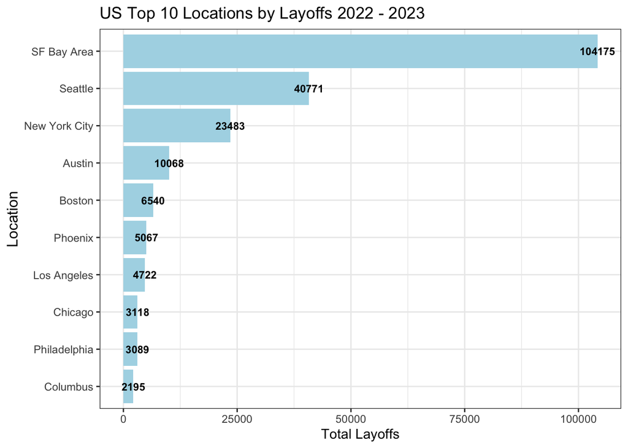

```r
# Count layoffs by location
layoffs_by_location <- layoffs_1%>%
  group_by(location) %>%
  summarize(total_layoffs = sum(total_laid_off))

# View the top 10 locations by layoffs
top_locations <- layoffs_by_location %>%
  arrange(desc(total_layoffs)) %>%
  head(10)


# Plot Top 10 locations by layoffs
ggplot(top_locations, aes(x = reorder(location, total_layoffs), y = total_layoffs)) +
  geom_col(fill = "light blue") +
  labs(title = "US Top 10 Locations by Layoffs 2022 - 2023", x = "Location", y = "Total Layoffs") +
    geom_text(aes(label=total_layoffs),size =3, fontface = "bold")+
  theme_bw() +
  theme(axis.title.y = element_text(size = 12)) +
  coord_flip()
```

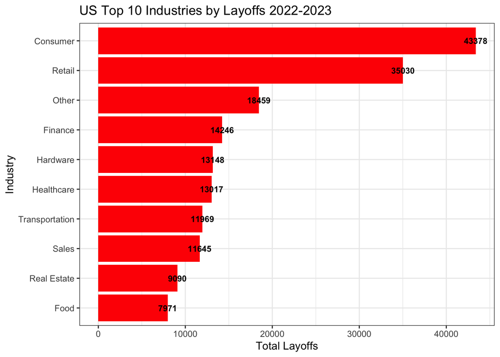

```r
# Count layoffs by industry
layoffs_by_industry <- layoffs_1 %>%
  group_by(industry) %>%
  summarize(total_layoffs = sum(total_laid_off))

# View the top 10 Industries by layoffs
top_industries <- layoffs_by_industry %>%
  arrange(desc(total_layoffs)) %>%
  head(10)


# Plot industries by layoffs
ggplot(top_industries, aes(x = reorder(industry, total_layoffs), y = total_layoffs)) +
  geom_col(fill = "red") +
  labs(title = "US Top 10 Industries by Layoffs 2022-2023", x = "Industry", y = "Total Layoffs") +
   geom_text(aes(label=total_layoffs),size =3,
   fontface = "bold")+
  theme_bw() +
  coord_flip()
```

# Analysis 2: Top 5 US companies with the most layoffs

The top 5 US companies that have laid off the most employees, will help to identify the companies that have been most affected by the economic slowdown and shed light on the factors that may have contributed to their layoffs.

Based on the latest analysis of the layoffs data for US companies, we found the following insights on the top 5 US companies:

Amazon: Since October 2022, Amazon has laid off a total of 27,150 employees over four rounds of layoffs. These layoffs were mainly related to the company’s efforts to streamline its operations and reduce costs.

Google: In this Janaury, Google has laid off a total of 12,000 employees.

Microsoft:In this Janaury, Microsoft has laid off a total of 10,000 employees.

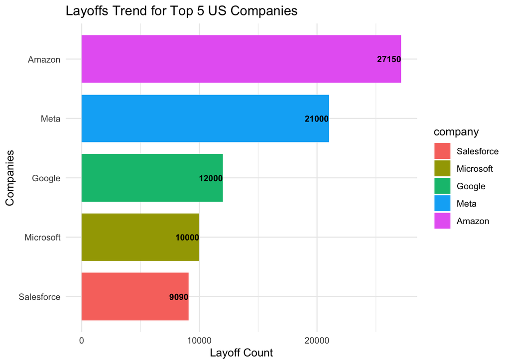

```r
# calculate total laid off
by_company <-layoffs_1 %>%
  group_by(company) %>%
  summarise(Total_count = sum(total_laid_off))

# get the top 5 companies data
top_5_companies <- by_company%>%
  slice_max(Total_count, n=5)

# plot in to the chart
top_5_companies %>%
mutate(company = fct_reorder(company, Total_count)) %>%
ggplot( aes(x=Total_count,y=company, fill=company))+
  geom_bar(stat='identity',width = 0.8) +
  geom_text(aes(label=Total_count),size =3,
    hjust = 1, nudge_x = -.5, fontface = "bold")+
  theme_minimal()+
    ggtitle("Layoffs Trend for Top 5 US Companies") +
      labs(y="Companies", x="Layoff Count")
```

```r
# get details of the top 5 companies
top_5_companies_details <-
  filter (layoffs_1,company %in% top_5_companies$company)

top_5_companies_details
```

```
## # A tibble: 11 × 6
##    company    location    industry total_laid_off date       country
##    <chr>      <chr>       <chr>             <dbl> <date>     <chr>
##  1 Amazon     Seattle     Retail              150 2022-10-28 United States
##  2 Amazon     Seattle     Retail            10000 2022-11-16 United States
##  3 Amazon     Seattle     Retail             8000 2023-01-04 United States
##  4 Amazon     Seattle     Retail             9000 2023-03-20 United States
##  5 Google     SF Bay Area Consumer          12000 2023-01-20 United States
##  6 Meta       SF Bay Area Consumer          11000 2022-11-09 United States
##  7 Meta       SF Bay Area Consumer          10000 2023-03-14 United States
##  8 Microsoft  Seattle     Other             10000 2023-01-18 United States
##  9 Salesforce SF Bay Area Sales                90 2022-10-13 United States
## 10 Salesforce SF Bay Area Sales              1000 2022-11-07 United States
## 11 Salesforce SF Bay Area Sales              8000 2023-01-04 United States
```

# Analysis 3: Top 5 US companies’ stock performance since August 2022

Based on the laid off date, look into the top 5 US companies’ stock performance since August 2022 and to analyze the impact of stock price. The relationship between the layoff dates and the stock prices of these companies will also provide interesting insights into the impact of layoffs on their financial performance.

### Create each company layoff date

```r
amazon_layoff<-
  filter (layoffs_1, company %in% "Amazon")

meta_layoff<-
  filter (layoffs_1, company %in% "Meta")

google_layoff<-
  filter (layoffs_1, company %in% "Google")

microsoft_layoff<-
  filter (layoffs_1, company %in% "Microsoft")

salesforce_layoff<-
  filter (layoffs_1, company %in% "Salesforce")
```

### Data 2: Download Historial Stock Price data from 2022-08-01 via Yahoo Finance

```r
# get amazon stock price
amazon <- tq_get('AMZN',
               from = "2022-08-01",
               get = "stock.prices")
# get meta stock price
meta <- tq_get('META',
               from = "2022-08-01",
               get = "stock.prices")
# get google stock price
google <- tq_get('GOOG',
               from = "2022-08-01",
               get = "stock.prices")
# get microsoft stock price
microsoft <- tq_get('MSFT',
               from = "2022-08-01",
               get = "stock.prices")
# get salesforce stock price
salesforce <- tq_get('CRM',
               from = "2022-08-01",
               get = "stock.prices")
```

## Amazon Stock Price 2022-2023 vs Layoffs

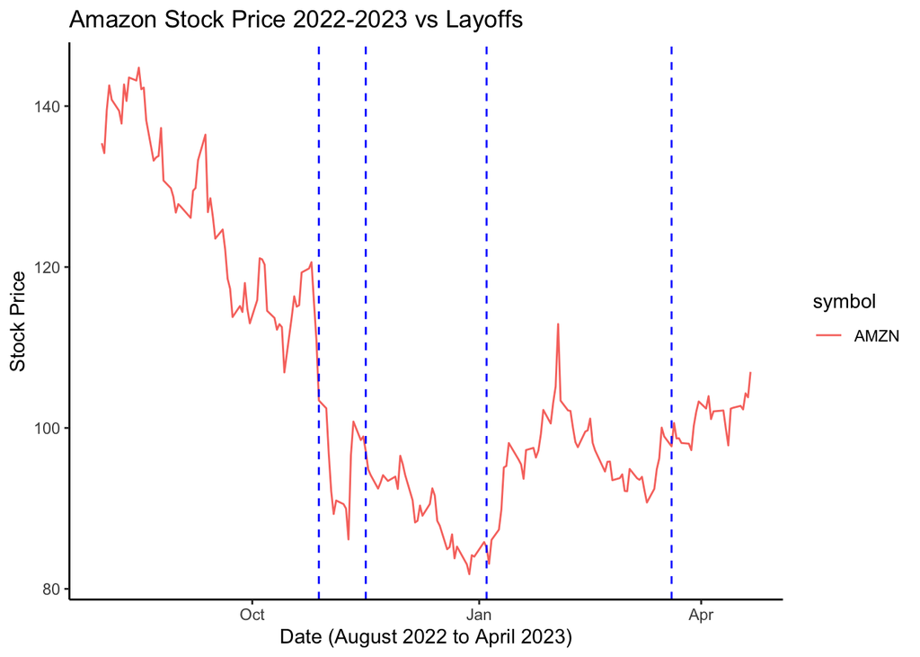

```r
# Plot the data using ggplot and geom_line
amazon %>%
  ggplot(aes(x = date, y = adjusted, color = symbol)) +
  geom_line() +
  theme_classic()+
# Add vertical lines using the date variable in the amazom layoff dataframe
  geom_vline(data=amazon_layoff, aes(xintercept =date), linetype = "dashed", color = "blue") +
    ggtitle("Amazon Stock Price 2022-2023 vs Layoffs") +
      labs(y="Stock Price", x="Date (August 2022 to April 2023)")
```

## Meta Stock Price 2022-2023 vs Layoffs

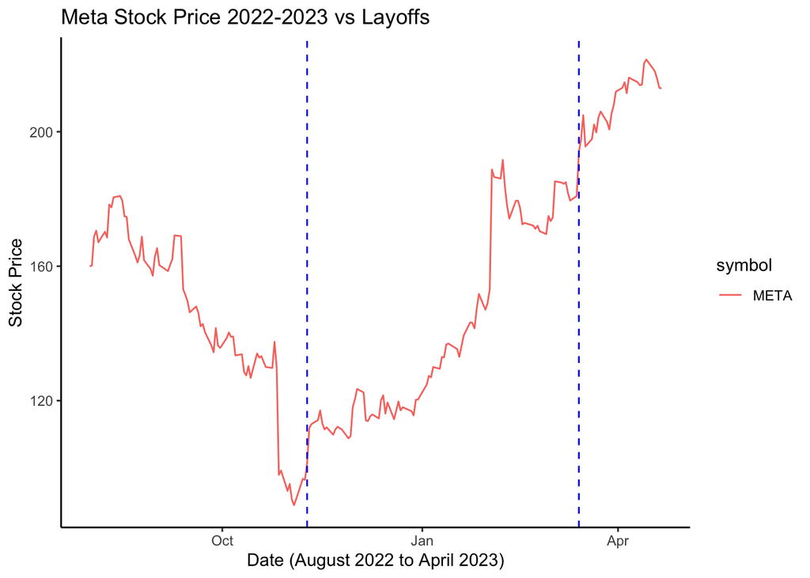

```r
meta %>%
  ggplot(aes(x = date, y = adjusted, color = symbol)) +
  geom_line() +
  theme_classic()+
  geom_vline(data=meta_layoff, aes(xintercept =date), linetype = "dashed", color = "blue") +
    ggtitle("Meta Stock Price 2022-2023 vs Layoffs") +
      labs(y="Stock Price", x="Date (August 2022 to April 2023)")
```

## Google Stock Price 2022-2023 vs Layoffs

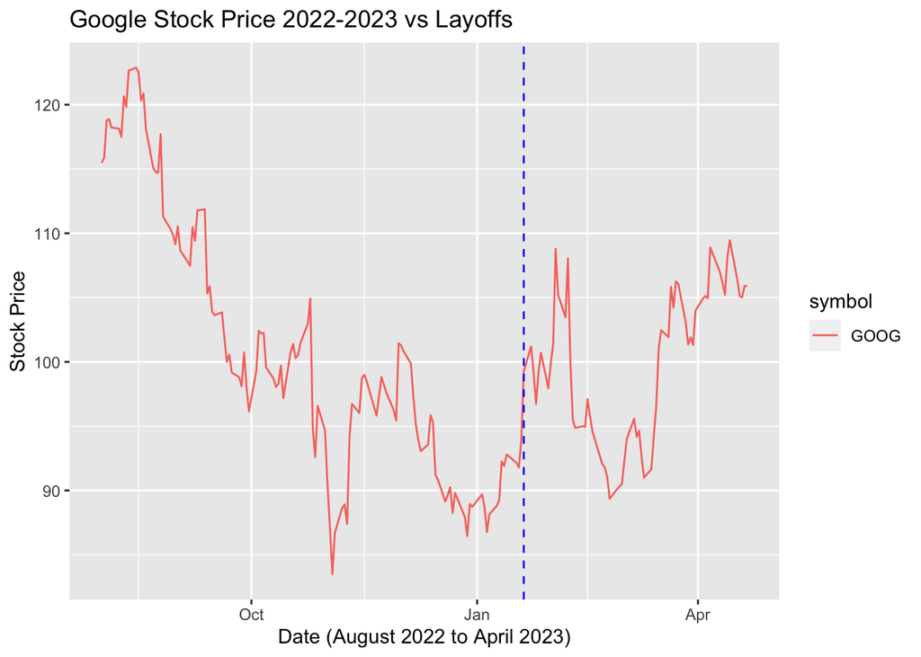

```r
google %>%
  ggplot(aes(x = date, y = adjusted, color = symbol)) +
  geom_line() +
  geom_vline(data=google_layoff, aes(xintercept =date), linetype = "dashed", color = "blue") +
      ggtitle("Google Stock Price 2022-2023 vs Layoffs") +
      labs(y="Stock Price", x="Date (August 2022 to April 2023)")
```

## Microsoft

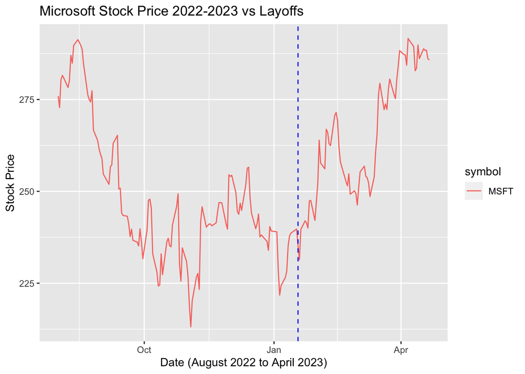

```r
microsoft %>%
  ggplot(aes(x = date, y = adjusted, color = symbol)) +
  geom_line() +
  geom_vline(data=microsoft_layoff, aes(xintercept =date), linetype = "dashed", color = "blue") +
      ggtitle("Microsoft Stock Price 2022-2023 vs Layoffs") +
      labs(y="Stock Price", x="Date (August 2022 to April 2023)")
```

## Salesforce

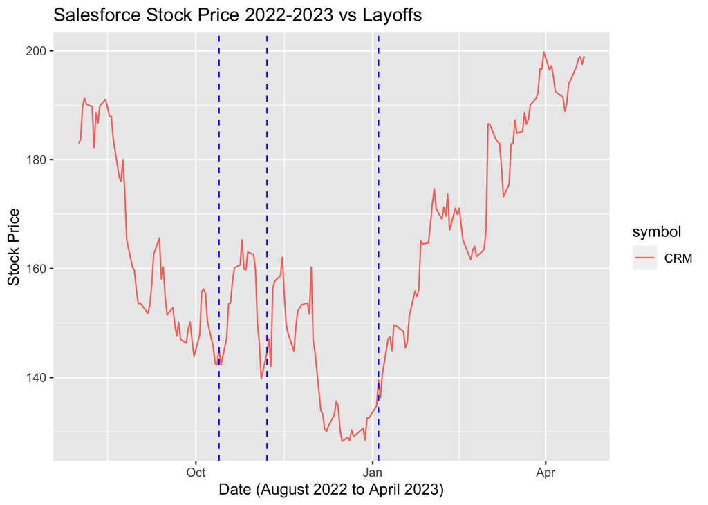

```r
salesforce %>%
  ggplot(aes(x = date, y = adjusted, color = symbol)) +
  geom_line() +
  geom_vline(data=salesforce_layoff, aes(xintercept =date), linetype = "dashed", color = "blue") +
      ggtitle("Salesforce Stock Price 2022-2023 vs Layoffs") +
      labs(y="Stock Price", x="Date (August 2022 to April 2023)")
```

# Analysis 4: Web scrapping for the current layoffs news from 3 different news websites

### Data 3: News Keyword - Web Scrapping

Obtain news headlines via 3 different news sites, WSJ, Business insider, and TechCrunch and searching “layoffs” keyword.

```r
library(rvest)
library(dplyr)

link_1 = "https://www.wsj.com/search?query=layoffs&mod=searchresults_viewallresults"
news_1 = read_html(link_1)

headlines_1 = news_1 %>%
  html_nodes("div:nth-child(5) .WSJTheme--headlineText--He1ANr9C") %>%
  html_text()

link_2 = "https://www.businessinsider.com/s?q=layoffs"
news_2 = read_html(link_2)

headlines_2 = news_2 %>%
  html_nodes(".tout-title-link") %>%
  html_text()

link_3 = "https://search.techcrunch.com/search;_ylc=X3IDMgRncHJpZANsLjlMRmdMblFlQ3BsNlJRQUpqaHNBBG5fc3VnZwM5BHBvcwMwBHBxc3RyAwRwcXN0cmwDMARxc3RybAM3BHF1ZXJ5A2xheW9mZnMEdF9zdG1wAzE2ODIwOTI1MTA-?p=layoffs&fr=techcrunch"
news_3 = read_html(link_3)

headlines_3 = news_3 %>%
  html_nodes(".fw-b") %>%
  html_text()


headlines_1
```

```
## character(0)
```

```r
headlines_2
```

```
##  [1] "Leaked memo reveals Disney's new finance structure as more layoffs loom, with a reported 15% of entertainment staffers to be cut"
##  [2] "Mark Zuckerberg isn't ruling out future layoffs at Meta 'given the volatility,' a report says"
##  [3] "Meta's latest layoffs: Here are more than a dozen jobs and teams hit most by this week's cuts"
##  [4] "Meta employees criticize Mark Zuckerberg's second round of layoffs in an internal forum: 'you've shattered the morale and confidence in leadership,' report says"
##  [5] "We mapped out the 113 most powerful people at Warner Bros. Discovery after a blockbuster merger and a tumultuous year of layoffs and cuts under CEO David Zaslav"
##  [6] "Meta's latest round of layoffs will hurt productivity and damage employee morale"
##  [7] "Meta is ramping up its investment in gaming projects even as layoffs hit the rest of the company"
##  [8] "Facebook’s parent company Meta is doing layoffs again. But there’s one ‘safe’ team that could actually benefit from the job cuts."
##  [9] "I'm a former Microsoft VP of HR. Here are the real reasons why layoffs are happening and how much longer they'll last."
## [10] "Meta's layoffs are affecting customer service and leaving influencers and businesses on Instagram and Facebook in the lurch, report says"
## [11] "How David Zaslav is transforming Warner Bros. Discovery, from layoffs and a major reorg to launching a new mega-streaming app, Max"
## [12] "Companies can't do layoffs right because they're trying to act like 'cool parents'"
## [13] "More layoffs may still come for tech workers"
## [14] "Softbank-backed adtech firm Permutive announces further layoffs, which could affect up to 40% of staff"
## [15] "Amazon salaries revealed: Here's how much engineers, data scientists, and thousands of other employees were paid before recent layoffs"
## [16] "CHART: We analyzed Apple's revenue per employee to show how it's avoided tech bloat and delayed layoffs"
## [17] "ABC News layoffs left insiders 'outraged' by how veteran execs' exits were handled"
## [18] "How tech layoffs could affect the economy"
## [19] "Read the full memo: McDonald's outlines plans for layoffs and shift in strategy"
## [20] "Tesla rival Lucid plans layoffs, as manufacturing and production challenges mount for EV startups"
```

```r
headlines_3
```

```
##  [1] "Elon Musk's Twitter: Everything you need to know, from layoffs to verification"
##  [2] "A comprehensive list of 2023 tech layoffs"
##  [3] "Meta can be sued in Kenya over alleged unlawful layoffs and blacklisting of moderators, court rules"
##  [4] "Another round of mass layoffs expected at Meta this week"
##  [5] "Roku announces a second set of layoffs impacting 200 employees, or 6% of its workforce"
##  [6] "The first round of Disney layoffs begins this week, CEO Bob Iger shares in memo"
##  [7] "Lyft hails new leadership, layoffs come for Lucid, and Waymo retires its self-driving minivan"
##  [8] "AWS takes a hit in latest round of Amazon layoffs"
##  [9] "Roofstock, valued at $1.9B last year, cuts 27% of staff in second round of layoffs"
## [10] "The layoffs will continue until (investor) morale improves"
```

### Perform a word cloud graphic

```r
# Combine the headlines from three pages
all_headlines <- c(headlines_1, headlines_2, headlines_3)

# Create a data frame with one column for the text
df <- data.frame(text = all_headlines)

# Tokenize the text and remove unwanted word
tokens <- df %>%
  unnest_tokens(word, text) %>%
  anti_join(stop_words) %>%
  filter(!word %in% c("layoffs")) %>%
  mutate(word = gsub("'s$", "", word))
```

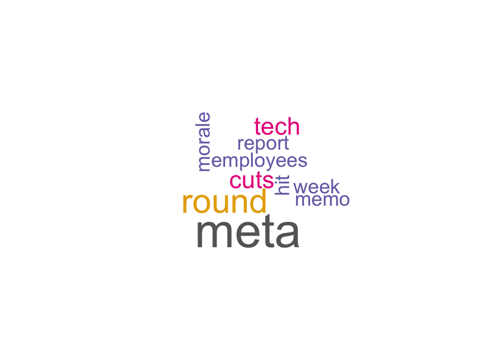

```r
# Create a frequency table of the words
word_freq <- tokens %>%
  count(word, sort = TRUE)

# Create a word cloud
wordcloud(word_freq$word, word_freq$n, max.words = 50, colors = brewer.pal(8, "Dark2"))
```

# Conclusion:

I focused on analyzing the top 5 US companies that have laid off the most employees since 2022, using their stock price data from August 2022. To conduct the analysis, I used the layoff dataset from Kaggle and historical stock price data.